# Models with many features: multiple regression

M Loecher

## Presenting lm output

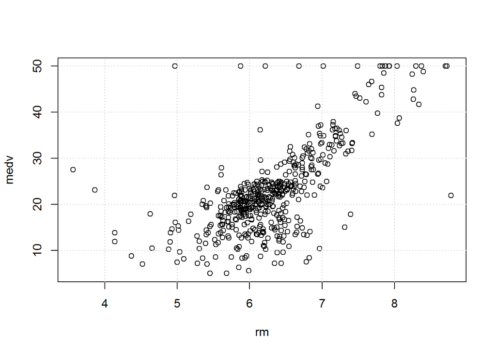

```r
library(MASS)
data(Boston)
plot(medv ~ rm, data = Boston);grid()
```

```r
fit1 = lm(medv ~ rm, data = Boston)
summary(fit1)
```

```
##
## Call:
## lm(formula = medv ~ rm, data = Boston)
##
## Residuals:
##     Min      1Q  Median      3Q     Max
## -23.346  -2.547   0.090   2.986  39.433
##
## Coefficients:
##             Estimate Std. Error t value Pr(>|t|)
## (Intercept)  -34.671      2.650  -13.08   <2e-16 ***
## rm             9.102      0.419   21.72   <2e-16 ***
## ---
## Signif. codes:  0 '***' 0.001 '**' 0.01 '*' 0.05 '.' 0.1 ' ' 1
##
## Residual standard error: 6.616 on 504 degrees of freedom
## Multiple R-squared:  0.4835, Adjusted R-squared:  0.4825
## F-statistic: 471.8 on 1 and 504 DF,  p-value: < 2.2e-16
```

```r
fit2 = lm(medv ~ rm + crim, data = Boston)
summary(fit2)
```

```
##
## Call:
## lm(formula = medv ~ rm + crim, data = Boston)
##
## Residuals:
##     Min      1Q  Median      3Q     Max
## -21.608  -2.835  -0.380   2.592  38.839
##
## Coefficients:
##              Estimate Std. Error t value Pr(>|t|)
## (Intercept) -29.24472    2.58809 -11.300   <2e-16 ***
## rm            8.39107    0.40485  20.726   <2e-16 ***
## crim         -0.26491    0.03307  -8.011    8e-15 ***
## ---
## Signif. codes:  0 '***' 0.001 '**' 0.01 '*' 0.05 '.' 0.1 ' ' 1
##
## Residual standard error: 6.237 on 503 degrees of freedom
## Multiple R-squared:  0.542,  Adjusted R-squared:  0.5401
## F-statistic: 297.6 on 2 and 503 DF,  p-value: < 2.2e-16
```

```r
fit3 = lm(medv ~ rm + crim + rad, data = Boston)
summary(fit3)
```

```
##
## Call:
## lm(formula = medv ~ rm + crim + rad, data = Boston)
##
## Residuals:
##     Min      1Q  Median      3Q     Max
## -18.882  -3.048  -0.600   2.347  40.842
##
## Coefficients:
##              Estimate Std. Error t value Pr(>|t|)
## (Intercept) -27.10363    2.60643 -10.399  < 2e-16 ***
## rm            8.23836    0.40081  20.554  < 2e-16 ***
## crim         -0.16549    0.04103  -4.034 6.35e-05 ***
## rad          -0.16133    0.04045  -3.989 7.62e-05 ***
## ---
## Signif. codes:  0 '***' 0.001 '**' 0.01 '*' 0.05 '.' 0.1 ' ' 1
##
## Residual standard error: 6.146 on 502 degrees of freedom
## Multiple R-squared:  0.556,  Adjusted R-squared:  0.5534
## F-statistic: 209.6 on 3 and 502 DF,  p-value: < 2.2e-16
```

```r
fit4a = fit4 = lm(medv ~ rm + crim + rad + dis + nox + age, data = Boston)
summary(fit4)
```

```
##
## Call:
## lm(formula = medv ~ rm + crim + rad + dis + nox + age, data = Boston)
##
## Residuals:
##     Min      1Q  Median      3Q     Max
## -17.548  -3.013  -0.836   1.927  39.488
##
## Coefficients:
##              Estimate Std. Error t value Pr(>|t|)
## (Intercept)  -7.20810    4.03247  -1.788  0.07446 .
## rm            7.75416    0.39435  19.663  < 2e-16 ***
## crim         -0.16765    0.03949  -4.246 2.60e-05 ***
## rad          -0.08873    0.04429  -2.003  0.04569 *
## dis          -1.19439    0.21610  -5.527 5.26e-08 ***
## nox         -15.11631    4.19907  -3.600  0.00035 ***
## age          -0.06738    0.01510  -4.461 1.01e-05 ***
## ---
## Signif. codes:  0 '***' 0.001 '**' 0.01 '*' 0.05 '.' 0.1 ' ' 1
##
## Residual standard error: 5.883 on 499 degrees of freedom
## Multiple R-squared:  0.5956, Adjusted R-squared:  0.5908
## F-statistic: 122.5 on 6 and 499 DF,  p-value: < 2.2e-16
```

```r
library(texreg)
#texreg(list(fit1,fit2,fit3,fit4)) #Latex output
htmlreg(list(fit1,fit2,fit3,fit4))
```

Statistical models

|  | **Model 1** | **Model 2** | **Model 3** | **Model 4** |  |
| --- | --- | --- | --- | --- | --- |
| (Intercept) | -34.67*** | -29.24*** | -27.10*** | -7.21 |  |
|  | (2.65) | (2.59) | (2.61) | (4.03) |  |
| rm | 9.10*** | 8.39*** | 8.24*** | 7.75*** |  |
|  | (0.42) | (0.40) | (0.40) | (0.39) |  |
| crim |  | -0.26*** | -0.17*** | -0.17*** |  |
|  |  | (0.03) | (0.04) | (0.04) |  |
| rad |  |  | -0.16*** | -0.09* |  |
|  |  |  | (0.04) | (0.04) |  |
| dis |  |  |  | -1.19*** |  |
|  |  |  |  | (0.22) |  |
| nox |  |  |  | -15.12*** |  |
|  |  |  |  | (4.20) |  |
| age |  |  |  | -0.07*** |  |
|  |  |  |  | (0.02) |  |
| R<sup>2</sup> | 0.48 | 0.54 | 0.56 | 0.60 |  |
| Adj. R<sup>2</sup> | 0.48 | 0.54 | 0.55 | 0.59 |  |
| Num. obs. | 506 | 506 | 506 | 506 |  |
| RMSE | 6.62 | 6.24 | 6.15 | 5.88 |  |
| p < 0.001, p < 0.01, p < 0.05 |  |  |  |  |  |

## Adjusted Rsquared

$$R^2 = 1- \frac{RSS}{TSS} \sim 1- \frac{\sigma^2_{e}}{\sigma^2_{y}}$$

$$R^2_{adj} = 1- \frac{RSS/(n-p-1)}{TSS/(n-1)} = 1- \frac{\sigma^2_{e}}{\sigma^2_{y}}$$
1. Refit model 4 for a random subset of 50 rows

```r
set.seed(123)
ranRows = sample(nrow(Boston), 50)
fit4a = fit4 = lm(medv ~ rm + crim + rad + dis + nox + age, data = Boston[ranRows,])
summary(fit4a)
```

```
##
## Call:
## lm(formula = medv ~ rm + crim + rad + dis + nox + age, data = Boston[ranRows,
##     ])
##
## Residuals:
##     Min      1Q  Median      3Q     Max
## -6.4645 -2.3777 -0.1788  2.2400  7.8256
##
## Coefficients:
##              Estimate Std. Error t value Pr(>|t|)
## (Intercept) -29.95104    9.11918  -3.284  0.00204 **
## rm           10.42144    0.83181  12.529 6.05e-16 ***
## crim         -0.14852    0.13290  -1.118  0.26995
## rad          -0.23969    0.09563  -2.506  0.01606 *
## dis          -0.94830    0.56464  -1.679  0.10032
## nox          -2.23613    9.04492  -0.247  0.80591
## age          -0.08865    0.03763  -2.356  0.02311 *
## ---
## Signif. codes:  0 '***' 0.001 '**' 0.01 '*' 0.05 '.' 0.1 ' ' 1
##
## Residual standard error: 3.977 on 43 degrees of freedom
## Multiple R-squared:  0.8597, Adjusted R-squared:  0.8402
## F-statistic: 43.93 on 6 and 43 DF,  p-value: < 2.2e-16
```

## model matrix

The function *model.matrix()* constructs the “X side” of the data, which is very straightforward for metric data:

```r
train <- read.csv("../../data/TitanicTrain.csv")

x1 = model.matrix(Survived ~ Age + Fare, data = train)
#no intercept
x1a = model.matrix(Survived ~ Age + Fare -1, data = train)

library(DT)

DT::datatable(cbind(x1,x1a), options = list(pageLength = 6))
```

|  | (Intercept) | Age | Fare | Age | Fare |
| --- | --- | --- | --- | --- | --- |
| 1 | 1 | 22 | 7.25 | 22 | 7.25 |
| 2 | 1 | 38 | 71.2833 | 38 | 71.2833 |
| 3 | 1 | 26 | 7.925 | 26 | 7.925 |
| 4 | 1 | 35 | 53.1 | 35 | 53.1 |
| 5 | 1 | 35 | 8.05 | 35 | 8.05 |
| 7 | 1 | 54 | 51.8625 | 54 | 51.8625 |
| 8 | 1 | 2 | 21.075 | 2 | 21.075 |
| 9 | 1 | 27 | 11.1333 | 27 | 11.1333 |
| 10 | 1 | 14 | 30.0708 | 14 | 30.0708 |
| 11 | 1 | 4 | 16.7 | 4 | 16.7 |

[output cut: 704 more lines]

## Dummy Coding

```r
train$Pclass = factor(train$Pclass)
#dummy coding
x2 = model.matrix(Survived ~ Age + Pclass, data = train)
#dummy coding, no intercept
x2a = model.matrix(Survived ~ Age + Pclass -1, data = train)

DT::datatable(cbind(x2,x2a), options = list(pageLength = 6))
```

|  | (Intercept) | Age | Pclass2 | Pclass3 | Age | Pclass1 | Pclass2 | Pclass3 |
| --- | --- | --- | --- | --- | --- | --- | --- | --- |
| 1 | 1 | 22 | 0 | 1 | 22 | 0 | 0 | 1 |
| 2 | 1 | 38 | 0 | 0 | 38 | 1 | 0 | 0 |
| 3 | 1 | 26 | 0 | 1 | 26 | 0 | 0 | 1 |
| 4 | 1 | 35 | 0 | 0 | 35 | 1 | 0 | 0 |
| 5 | 1 | 35 | 0 | 1 | 35 | 0 | 0 | 1 |
| 7 | 1 | 54 | 0 | 0 | 54 | 1 | 0 | 0 |
| 8 | 1 | 2 | 0 | 1 | 2 | 0 | 0 | 1 |
| 9 | 1 | 27 | 0 | 1 | 27 | 0 | 0 | 1 |
| 10 | 1 | 14 | 1 | 0 | 14 | 0 | 1 | 0 |
| 11 | 1 | 4 | 0 | 1 | 4 | 0 | 0 | 1 |

[output cut: 704 more lines]

#### Interpretation as intercept, not slope !

```r
library(ISLR)
#The "Credit" data:
data(Default)

fit2a = lm(balance ~ income + student-1, data = Default)
summary(fit2a)
```

```
##
## Call:
## lm(formula = balance ~ income + student - 1, data = Default)
##
## Residuals:
##     Min      1Q  Median      3Q     Max
## -988.99 -347.23  -10.58  320.27 1726.04
##
## Coefficients:
##             Estimate Std. Error t value Pr(>|t|)
## income     1.052e-04  5.407e-04   0.195    0.846
## studentNo  7.676e+02  2.236e+01  34.334   <2e-16 ***
## studentYes 9.859e+02  1.305e+01  75.532   <2e-16 ***
## ---
## Signif. codes:  0 '***' 0.001 '**' 0.01 '*' 0.05 '.' 0.1 ' ' 1
##
## Residual standard error: 473.6 on 9997 degrees of freedom
## Multiple R-squared:  0.7593, Adjusted R-squared:  0.7593
## F-statistic: 1.051e+04 on 3 and 9997 DF,  p-value: < 2.2e-16
```

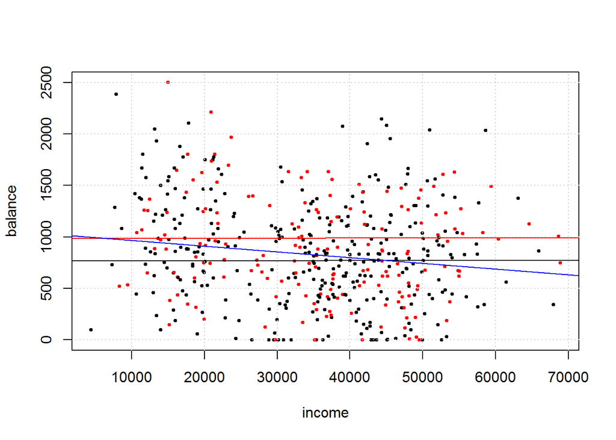

```r
coefs=coefficients(fit2a)


plot(balance ~ income, data = Default[sample(nrow(Default),500),], pch=20, cex=0.75, col = student);grid()

abline(a=coefs[2],b=coefs[1],col=1)
abline(a=coefs[3],b=coefs[1],col=2)

fit2b = lm(balance ~ income, data = Default)
coefs2=coefficients(fit2b)
abline(a=coefs2[1],b=coefs2[2],col="blue")
```

### Simpsons Paradox!

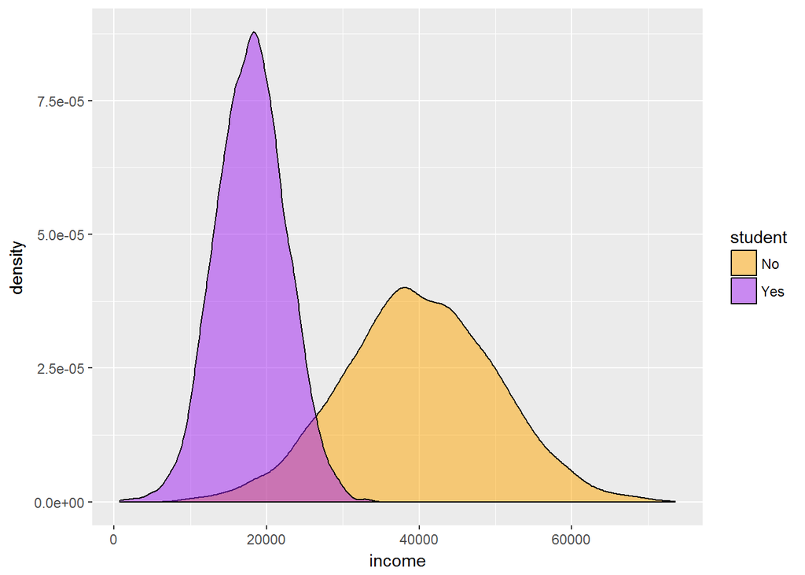

```r
library(ggplot2)
ggplot(Default, aes(income, fill=student)) + geom_density(alpha=.5) +
  scale_fill_manual(values = c("orange", "purple"))
```

## Interactions, revisited

```r
fit2c = lm(balance ~ income*student, data = Default)
summary(fit2c)
```

```
##
## Call:
## lm(formula = balance ~ income * student, data = Default)
##
## Residuals:
##      Min       1Q   Median       3Q      Max
## -1004.74  -347.04   -10.84   320.42  1724.01
##
## Coefficients:
##                     Estimate Std. Error t value Pr(>|t|)
## (Intercept)        7.605e+02  2.323e+01  32.733  < 2e-16 ***
## income             2.819e-04  5.633e-04   0.501    0.617
## studentYes         2.625e+02  4.256e+01   6.169 7.15e-10 ***
## income:studentYes -2.243e-03  2.007e-03  -1.118    0.264
## ---
## Signif. codes:  0 '***' 0.001 '**' 0.01 '*' 0.05 '.' 0.1 ' ' 1
##
## Residual standard error: 473.6 on 9996 degrees of freedom
## Multiple R-squared:  0.04157,    Adjusted R-squared:  0.04128
## F-statistic: 144.5 on 3 and 9996 DF,  p-value: < 2.2e-16
```

#### Synergy

```r
#Table 3.9 on  page 88 in ISL book
Advertising <- read.csv("../../data/Advertising.csv")
#get rid of the first column
Advertising <- Advertising[,-1]

fit3= lm(Sales ~ TV + Radio + TV:Radio, data = Advertising)
summary(fit3)
```

```
##
## Call:
## lm(formula = Sales ~ TV + Radio + TV:Radio, data = Advertising)
##
## Residuals:
##     Min      1Q  Median      3Q     Max
## -6.3366 -0.4028  0.1831  0.5948  1.5246
##
## Coefficients:
##              Estimate Std. Error t value Pr(>|t|)
## (Intercept) 6.750e+00  2.479e-01  27.233   <2e-16 ***
## TV          1.910e-02  1.504e-03  12.699   <2e-16 ***
## Radio       2.886e-02  8.905e-03   3.241   0.0014 **
## TV:Radio    1.086e-03  5.242e-05  20.727   <2e-16 ***
## ---
## Signif. codes:  0 '***' 0.001 '**' 0.01 '*' 0.05 '.' 0.1 ' ' 1
##
## Residual standard error: 0.9435 on 196 degrees of freedom
## Multiple R-squared:  0.9678, Adjusted R-squared:  0.9673
## F-statistic:  1963 on 3 and 196 DF,  p-value: < 2.2e-16
```

### Interactions between qualitative and quantitative variables

```r
library(ISLR)
#The "Credit" data:
data(Default)

#Eq. 3.34
fit3_34 = lm(balance ~ income + student, data = Default)
summary(fit3_34)
```

```
##
## Call:
## lm(formula = balance ~ income + student, data = Default)
##
## Residuals:
##     Min      1Q  Median      3Q     Max
## -988.99 -347.23  -10.58  320.27 1726.04
##
## Coefficients:
##              Estimate Std. Error t value Pr(>|t|)
## (Intercept) 7.676e+02  2.236e+01  34.334   <2e-16 ***
## income      1.052e-04  5.407e-04   0.195    0.846
## studentYes  2.184e+02  1.582e+01  13.804   <2e-16 ***
## ---
## Signif. codes:  0 '***' 0.001 '**' 0.01 '*' 0.05 '.' 0.1 ' ' 1
##
## Residual standard error: 473.6 on 9997 degrees of freedom
## Multiple R-squared:  0.04145,    Adjusted R-squared:  0.04126
## F-statistic: 216.1 on 2 and 9997 DF,  p-value: < 2.2e-16
```

```r
fit3_35 = lm(balance ~ income + student + income:student, data = Default)
summary(fit3_35)
```

```
##
## Call:
## lm(formula = balance ~ income + student + income:student, data = Default)
##
## Residuals:
##      Min       1Q   Median       3Q      Max
## -1004.74  -347.04   -10.84   320.42  1724.01
##
## Coefficients:
##                     Estimate Std. Error t value Pr(>|t|)
## (Intercept)        7.605e+02  2.323e+01  32.733  < 2e-16 ***
## income             2.819e-04  5.633e-04   0.501    0.617
## studentYes         2.625e+02  4.256e+01   6.169 7.15e-10 ***
## income:studentYes -2.243e-03  2.007e-03  -1.118    0.264
## ---
## Signif. codes:  0 '***' 0.001 '**' 0.01 '*' 0.05 '.' 0.1 ' ' 1
##
## Residual standard error: 473.6 on 9996 degrees of freedom
## Multiple R-squared:  0.04157,    Adjusted R-squared:  0.04128
## F-statistic: 144.5 on 3 and 9996 DF,  p-value: < 2.2e-16
```

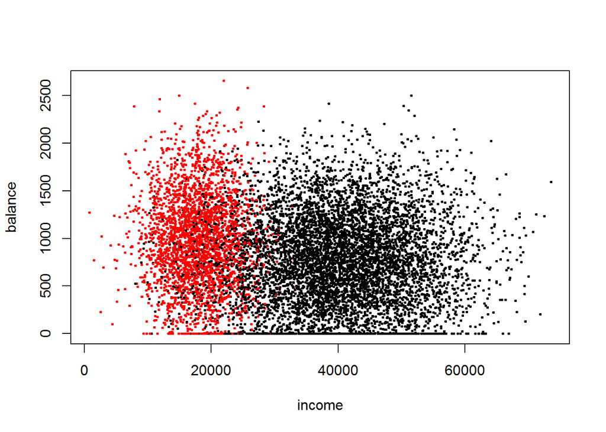

```r
plot(balance ~ income,col= student, data = Default, pch=20, cex=0.5)
```

#### R notation: * vs. :

```r
fit3_35b = lm(balance ~ income*student, data = Default)
summary(fit3_35b)
```

```
##
## Call:
## lm(formula = balance ~ income * student, data = Default)
##
## Residuals:
##      Min       1Q   Median       3Q      Max
## -1004.74  -347.04   -10.84   320.42  1724.01
##
## Coefficients:
##                     Estimate Std. Error t value Pr(>|t|)
## (Intercept)        7.605e+02  2.323e+01  32.733  < 2e-16 ***
## income             2.819e-04  5.633e-04   0.501    0.617
## studentYes         2.625e+02  4.256e+01   6.169 7.15e-10 ***
## income:studentYes -2.243e-03  2.007e-03  -1.118    0.264
## ---
## Signif. codes:  0 '***' 0.001 '**' 0.01 '*' 0.05 '.' 0.1 ' ' 1
##
## Residual standard error: 473.6 on 9996 degrees of freedom
## Multiple R-squared:  0.04157,    Adjusted R-squared:  0.04128
## F-statistic: 144.5 on 3 and 9996 DF,  p-value: < 2.2e-16
```

## Ceteris Paribus, revisited

### Beer & Chips

```r
set.seed(123)
N=100
NumBeers = rpois(N,1.5)
#par(cex=1.5);barplot(table(NumBeers), xlab = "number beers", col = "bisque");grid()
NumChips = 15*NumBeers
Headache = 0.5*NumBeers + 0.1*NumChips
#Headache = pmax(0.5*NumBeers + 0.1*NumChips,0)
x=cbind.data.frame(NumBeers,NumChips,Headache)
fit1=lm(Headache ~ NumBeers,data=x)
summary(fit1)
```

```
##
## Call:
## lm(formula = Headache ~ NumBeers, data = x)
##
## Residuals:
##        Min         1Q     Median         3Q        Max
## -2.134e-14  1.224e-16  1.900e-16  1.900e-16  2.494e-15
##
## Coefficients:
##              Estimate Std. Error   t value Pr(>|t|)
## (Intercept) 2.487e-15  3.478e-16 7.151e+00 1.56e-10 ***
## NumBeers    2.000e+00  1.841e-16 1.087e+16  < 2e-16 ***
## ---
## Signif. codes:  0 '***' 0.001 '**' 0.01 '*' 0.05 '.' 0.1 ' ' 1
##
## Residual standard error: 2.185e-15 on 98 degrees of freedom
## Multiple R-squared:      1,  Adjusted R-squared:      1
## F-statistic: 1.181e+32 on 1 and 98 DF,  p-value: < 2.2e-16
```

```r
fit2=lm(Headache ~ NumChips,data=x)
summary(fit2)
```

```
##
## Call:
## lm(formula = Headache ~ NumChips, data = x)
##
## Residuals:
##        Min         1Q     Median         3Q        Max
## -2.239e-14  3.569e-16  4.665e-16  4.693e-16  5.818e-16
##
## Coefficients:
##              Estimate Std. Error   t value Pr(>|t|)
## (Intercept) 3.553e-16  4.876e-16 7.290e-01    0.468
## NumChips    1.333e-01  1.721e-17 7.749e+15   <2e-16 ***
## ---
## Signif. codes:  0 '***' 0.001 '**' 0.01 '*' 0.05 '.' 0.1 ' ' 1
##
## Residual standard error: 3.064e-15 on 98 degrees of freedom
## Multiple R-squared:      1,  Adjusted R-squared:      1
## F-statistic: 6.005e+31 on 1 and 98 DF,  p-value: < 2.2e-16
```

```r
fit3=lm(Headache ~ NumBeers + NumChips,data=x)
summary(fit3)
```

```
##
## Call:
## lm(formula = Headache ~ NumBeers + NumChips, data = x)
##
## Residuals:
##        Min         1Q     Median         3Q        Max
## -2.134e-14  1.224e-16  1.900e-16  1.900e-16  2.494e-15
##
## Coefficients: (1 not defined because of singularities)
##              Estimate Std. Error   t value Pr(>|t|)
## (Intercept) 2.487e-15  3.478e-16 7.151e+00 1.56e-10 ***
## NumBeers    2.000e+00  1.841e-16 1.087e+16  < 2e-16 ***
## NumChips           NA         NA        NA       NA
## ---
## Signif. codes:  0 '***' 0.001 '**' 0.01 '*' 0.05 '.' 0.1 ' ' 1
##
## Residual standard error: 2.185e-15 on 98 degrees of freedom
## Multiple R-squared:      1,  Adjusted R-squared:      1
## F-statistic: 1.181e+32 on 1 and 98 DF,  p-value: < 2.2e-16
```

#### Collinearity, False Negatives

```r
set.seed(123)
N=100
NumBeers = rpois(N,1.5)
#par(cex=1.5);barplot(table(NumBeers), xlab = "number beers", col = "bisque");grid()
NumChips = 15*NumBeers + rnorm(N,s=0.001)
Headache = 0.5*NumBeers + 0.1*NumChips  + rnorm(N,s=1)
#Headache = pmax(0.5*NumBeers + 0.1*NumChips,0)
x=cbind.data.frame(NumBeers,NumChips,Headache)
fit1=lm(Headache ~ NumBeers,data=x)
fit2=lm(Headache ~ NumChips,data=x)
fit3=lm(Headache ~ NumBeers + NumChips,data=x)
summary(fit3)
```

```
##
## Call:
## lm(formula = Headache ~ NumBeers + NumChips, data = x)
##
## Residuals:
##     Min      1Q  Median      3Q     Max
## -1.3700 -0.7094 -0.2090  0.5211  3.1323
##
## Coefficients:
##               Estimate Std. Error t value Pr(>|t|)
## (Intercept)   -0.02453    0.14973  -0.164    0.870
## NumBeers    1258.54262 1469.53106   0.856    0.394
## NumChips     -83.76791   97.96879  -0.855    0.395
##
## Residual standard error: 0.9403 on 97 degrees of freedom
## Multiple R-squared:  0.8708, Adjusted R-squared:  0.8682
## F-statistic:   327 on 2 and 97 DF,  p-value: < 2.2e-16
```

## The F test

#### False Positives

Create some VERY random data:

```r
Nrows=200;Ncols=20

ranData = matrix(rnorm(Nrows*Ncols),ncol=Ncols)
colnames(ranData) = c("Y", paste0("X",1:(Ncols-1)))
ranData = as.data.frame(ranData)
#build a model with ALL x variables
fit = lm(Y ~ . , data = ranData)
summary(fit)
```

```
##
## Call:
## lm(formula = Y ~ ., data = ranData)
##
## Residuals:
##      Min       1Q   Median       3Q      Max
## -3.12265 -0.61095 -0.02345  0.70129  2.44709
##
## Coefficients:
##              Estimate Std. Error t value Pr(>|t|)
## (Intercept) -0.005504   0.076171  -0.072    0.942
## X1          -0.076488   0.080908  -0.945    0.346
## X2           0.042607   0.073282   0.581    0.562
## X3           0.084335   0.073094   1.154    0.250
## X4          -0.018822   0.079500  -0.237    0.813
## X5           0.032165   0.082504   0.390    0.697
## X6           0.055319   0.077572   0.713    0.477
## X7          -0.066861   0.074930  -0.892    0.373
## X8           0.112773   0.073254   1.539    0.125
## X9          -0.011442   0.085852  -0.133    0.894
## X10         -0.022727   0.077176  -0.294    0.769
## X11          0.036268   0.076900   0.472    0.638
## X12         -0.068092   0.077236  -0.882    0.379
## X13          0.002081   0.073825   0.028    0.978
## X14          0.003233   0.077524   0.042    0.967
## X15          0.132141   0.080071   1.650    0.101
## X16         -0.069871   0.072195  -0.968    0.334
## X17         -0.067859   0.085803  -0.791    0.430
## X18          0.008470   0.071657   0.118    0.906
## X19          0.047094   0.087114   0.541    0.589
##
## Residual standard error: 1.034 on 180 degrees of freedom
## Multiple R-squared:  0.06389,    Adjusted R-squared:  -0.03492
## F-statistic: 0.6466 on 19 and 180 DF,  p-value: 0.8661
```

### Exercise

Suppose we have a data set with five predictors, $X1 = \mathrm{GPA}$, $X2 = \mathrm{IQ}$, $X3 = \mathrm{Gender}$ (1 for Female and 0 for Male), $X4 = \mathrm{Interaction\ between\ GPA\ and\ IQ}$, and $X5 = \mathrm{Interaction\ between\ GPA\ and\ Gender}$. The response is starting salary after graduation (in thousands of dollars). Suppose we use least squares to fit the model, and get $\hat{\beta_0} = 50$, $\hat{\beta_1} = 20$, $\hat{\beta_2} = 0.07$, $\hat{\beta_3} = 35$, $\hat{\beta_4} = 0.01$, $\hat{\beta_5} = -10$.

1. Which answer is correct, and why?
1. For a fixed value of IQ and GPA, males earn more on average than females.
2. For a fixed value of IQ and GPA, females earn more on average than males.
3. For a fixed value of IQ and GPA, males earn more on average than females provided that the GPA is high enough.
4. For a fixed value of IQ and GPA, females earn more on average than males provided that the GPA is high enough.
2. Predict the salary of a female with IQ of 110 and a GPA of 4.0.
3. True or false: Since the coefficient for the GPA/IQ interaction term is very small, there is very little evidence of an interaction effect. Justify your answer.

## Classification

### Interpretation of the coefficients in logistic regression

Fitting a logistic regression (*LR*) model (with Age, Sex and Pclass as predictors) to the survival outcome in the Titanic data yields a summary such as this one:

[output not shown]

```
##           1
## -0.03875556
```

```
##         1
## 0.4837526
```

```
##
## Call:
## glm(formula = Survived ~ Age + Sex + Pclass, family = binomial(link = logit),
##     data = NoMissingAge)
##
## Deviance Residuals:
##     Min       1Q   Median       3Q      Max
## -2.7303  -0.6780  -0.3953   0.6485   2.4657
##
## Coefficients:
##              Estimate Std. Error z value Pr(>|z|)
## (Intercept)  3.777013   0.401123   9.416  < 2e-16 ***
## Age         -0.036985   0.007656  -4.831 1.36e-06 ***
## Sexmale     -2.522781   0.207391 -12.164  < 2e-16 ***
## Pclass2     -1.309799   0.278066  -4.710 2.47e-06 ***
## Pclass3     -2.580625   0.281442  -9.169  < 2e-16 ***
## ---
## Signif. codes:  0 '***' 0.001 '**' 0.01 '*' 0.05 '.' 0.1 ' ' 1
##
## (Dispersion parameter for binomial family taken to be 1)
##
##     Null deviance: 964.52  on 713  degrees of freedom
## Residual deviance: 647.28  on 709  degrees of freedom
## AIC: 657.28
##
## Number of Fisher Scoring iterations: 5
```

```
##          1          2          3          4          5          7
## -0.4716467  0.4224490  1.0794775  0.4005642 -0.3747404 -0.8821915
```

```
##          1          2          3          4          5          7
## -0.4716467  0.4224490  1.0794775  0.4005642 -0.3747404 -0.8821915
```

For “normal regression” we know that the value of $\beta_j$ simply gives us $\Delta y$ if $x_j$ is increased by one unit.

In order to fully understand the exact meaning of the coefficients for a LR model we need to first warm up to the definition of a **link function** and the concept of **probability odds**.

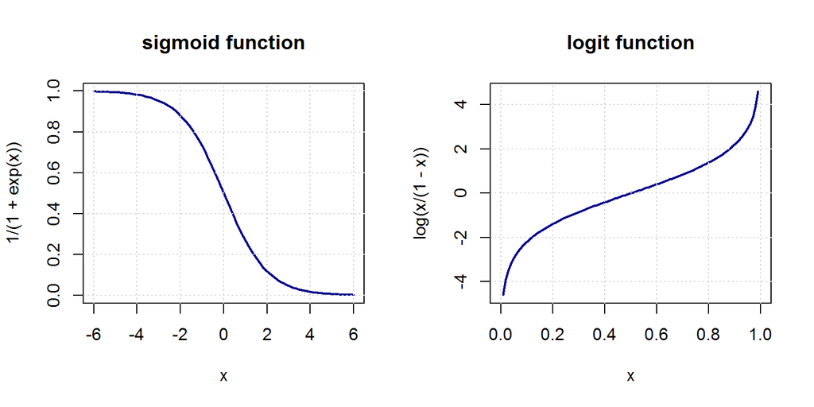

Finally, we can interpret the coefficients directly: the odds of a positive outcome are multiplied by a factor of $exp(\beta_j)$ for every unit change in $x_j$. (In that light, logistic regression is reminiscient of linear regression with logarithmically transformed dependent variable which also leads to multiplicative rather than additive effects.)

As an example, the coefficient for Pclass 3 is -2.5806, which means that the odds of survival compared to the reference level Pclass 1 are reduced by a factor of $exp(-2.5806) = 0.0757$;with all other input variables unchanged. How does the relative change in odds translate into probabilities? It is relatively easy to memorize the to and forth relationship between odds and probability $p$:
$$odds = \frac{p}{1-p} \Leftrightarrow p = \frac{odds}{1 + odds}$$
So the intercept 3.777 (= log-odds!) translates into odds of $exp(3.777) = 43.685$ which yields a base probability of survival (for female Pclass1 of age 0) of $43.685/(1 + 43.685) = 0.978$

#### Why make life so complicated?

Do we have to go through the constant trouble of (i) exponentiating the coefficients, (ii) multiplying the odds and finally (iii) compute the resulting probabilities? Can we not simply transform the coefficients from the summary table such that we can read off their effects directly - just like in linear regression?

The trouble is that there is no simple way to translate the coefficients into an additive or even a multiplicative adjustment of the probabilities. (One simple way to see this is the impossibility of keeping the output bounded between 0 and 1) The following graph shows the effect of various coefficient values on a base/reference probability.

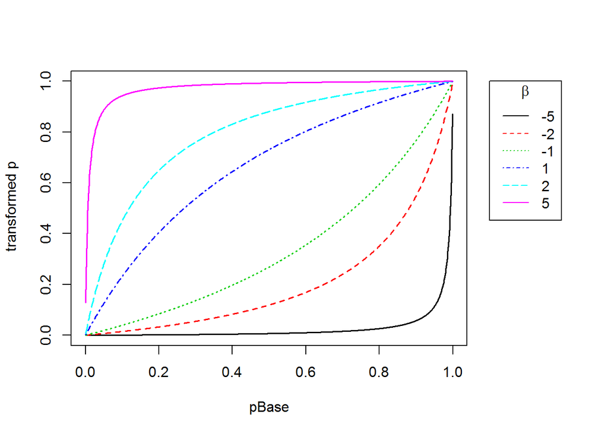

We immediately see that there is no straightforward additive or multiplicative effect that could be quantified.